# DEB AI-Systems

Hands on developing AI-Systems

Author

Affiliation

Prof. Johannes Baumgartl

Hochschule Esslingen

Published

March 9, 2026

# 1 KI-System

**ImportantMission Statement of the Lecture**

This lecture is about the development and deployment of AI systems, which includes the technical, evaluative, practical, and ethical dimensions of AI literacy. The lecture will cover topics such as model training, model optimization, infrastructure, deployment, monitoring, regulations, ethics, cost management, sustainability, and trends in AI systems. The goal is to equip students with the knowledge and skills to build and manage AI systems responsibly and effectively.

> What is AI Literacy and why is it important for the development and deployment of AI systems?

> What are the goals of the lecture KI-Systeme and the lab project?

> What is the definition of AI systems?

# 2 Data & AI Literacy

**TipLiteracy Long and Magerko ([2020](https://moodle.hs-esslingen.de/moodle/pluginfile.php/742408/mod_resource/content/1/DEB-KI-Systeme-Lec00.Intro.html#ref-Long2020-ai-literacy))**

is the “ability to express ourselves and communicate using written language.”

In contrast:

Data and AI literacy refers to the ability to understand, apply and critically evaluate data and AI-based systems.

As a refresher: [Figure 1](https://moodle.hs-esslingen.de/moodle/pluginfile.php/742408/mod_resource/content/1/DEB-KI-Systeme-Lec00.Intro.html#fig-data-value-creation) visualizes the data value creation scheme. It is the baseline for the upcoming definitions and consequences.

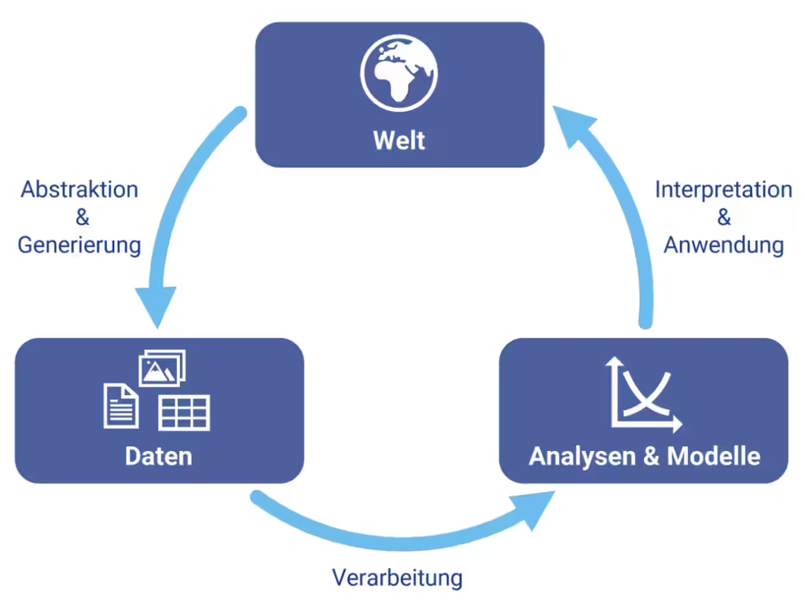

Figure 1: Scheme for data value creation. Source: Jena ([2026](https://moodle.hs-esslingen.de/moodle/pluginfile.php/742408/mod_resource/content/1/DEB-KI-Systeme-Lec00.Intro.html#ref-UniJena26-data-ai-literacy))

## 2.1 What is AI Literacy?

A new terminology has emerged in the context of the increasing prevalence of AI technologies: **AI Literacy**. This concept encompasses a set of competencies that enable individuals to

- critically **evaluate** AI technologies,
- **communicate** and
- **collaborate** effectively with AI, and
- **use** AI as a tool in various contexts, including online, at home, and in the workplace.

The importance of AI literacy is underscored by the EU AI Act (2024/1689).

[figure not shown]

From literacy to AI literacy to legal obligation — a process overview.

## 2.2 What competences does one need?

**TipAI literacy Long and Magerko ([2020](https://moodle.hs-esslingen.de/moodle/pluginfile.php/742408/mod_resource/content/1/DEB-KI-Systeme-Lec00.Intro.html#ref-Long2020-ai-literacy))**

is a **set of competencies** that enables individuals to **critically evaluate** AI technologies; **communicate** and **collaborate effectively** with AI; and **use AI as a tool** online, at home, and in the workplace.

The definition breaks down into the following competencies:

- **Technical**: Recognizing what AI is, how it works, and what it can and cannot do.
- **Evaluative**: Critically evaluating AI tool applications and outputs, with an emphasis on developing robust AI impact assessment tools and frameworks.
- **Practical**: Effectively applying, integrating, and managing AI tools across teaching, scholarship, and educational administration.
- **Ethical**: Formulating and enforcing institutional strategies to safeguard against biases and the misuse or misapplication of AI technologies.

**TipConsequences in the EU AI Act[[^1]](https://moodle.hs-esslingen.de/moodle/pluginfile.php/742408/mod_resource/content/1/DEB-KI-Systeme-Lec00.Intro.html#fn1)**

**Providers** and **deployers** of **AI systems** shall take measures to **ensure**, to their best extent, a **sufficient level of AI literacy** of their staff and other persons dealing with the operation and use of AI systems on their behalf, taking into account their technical knowledge, experience, education and training and the context the AI systems are to be used in, and considering the persons or groups of persons on whom the AI systems are to be used.

## 2.3 Competences in Context[[^2]](https://moodle.hs-esslingen.de/moodle/pluginfile.php/742408/mod_resource/content/1/DEB-KI-Systeme-Lec00.Intro.html#fn2)

Digital technologies, data-driven processes and AI systems are having an ever-greater impact on science, the world of work and social processes.

The competent use of data and AI is therefore not a specialised skill reserved for individual experts, but a fundamental key competence for students across all disciplines.

[Figure 2](https://moodle.hs-esslingen.de/moodle/pluginfile.php/742408/mod_resource/content/1/DEB-KI-Systeme-Lec00.Intro.html#fig-literacy-competences) shows important competences and expertise for professionals. These apply independently from the domain.

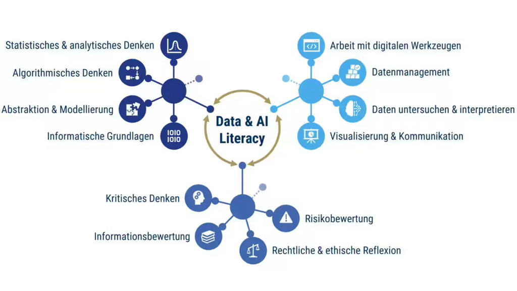

Figure 2: Network of expertise in data literacy. Source: Jena ([2026](https://moodle.hs-esslingen.de/moodle/pluginfile.php/742408/mod_resource/content/1/DEB-KI-Systeme-Lec00.Intro.html#ref-UniJena26-data-ai-literacy))

**TipAt a Glance**

Data & AI literacy enables people to:

- understand and critically evaluate data-driven findings,
- use digital tools to organise, process and analyse data,
- use AI tools thoughtfully and responsibly,
- evaluate information sources and algorithmic systems,
- and actively shape digital developments in academia, the workplace and society.

In doing so, it enhances both the quality of academic work and the ability to participate responsibly in an increasingly data-driven world.

# 3 Goals of the Lecture KI-Systeme and Lab-Project

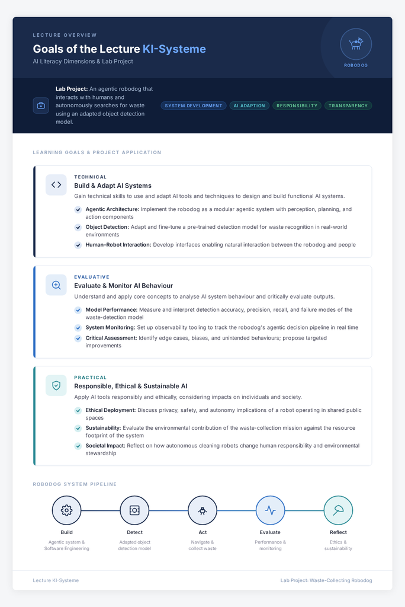

Goals of the lecture with respect to the lab project

**ImportantDeliverables and Guidelines of the Lab Project**

The deliverables of the lab project will include:

- A **working prototype** of a robot dog that can be controlled using an agent-based control system and can perform object detection using a fine-tuned model.
- A **report documenting** the development process, including the design decisions, the tools used, the evaluation results, and the ethical considerations taken into account. Baseline is the AI-Policy and the evaluation criteria defined for the AI tools.
- A **legal analysis** of the project, considering the relevant regulations and ethical guidelines for AI systems.
- A **cost analysis** of the runtime costs of the system.
- A **ethical analysis** of the potential impacts of the system on individuals and society, including considerations of bias, fairness, and privacy.
- A **presentation** summarizing the project and its outcomes.
- **Prompt or Interaction Database** for the selected tooling

Important:

- The demonstration should focus on reproducible and explainable results, not only on the performance of the system.
- The documentation is in markdown.
- The project was developed using github using branches and pull requests.
- The project uses the tech stack defined in the lecture.

# 4 AI Systems Definition

Motivation for the definition of AI systems is the history of robotics and AI ([Figure 3](https://moodle.hs-esslingen.de/moodle/pluginfile.php/742408/mod_resource/content/1/DEB-KI-Systeme-Lec00.Intro.html#fig-history-ai-systems)).

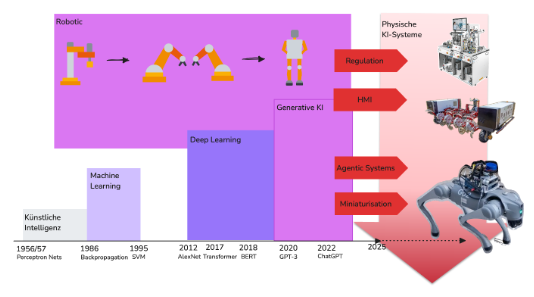

Figure 3: Development of Robotics and AI

**Tip(Physical) AI-System**

A machine-based system designed to operate with varying **degrees of autonomy** and demonstrate adaptability after its introduction, which **derives** explicit or implicit **objectives** from the inputs it receives and **generates outputs** such as predictions, content, recommendations or decisions that **may influence** physical or virtual **environments**.

[Survey](https://particify.hs-esslingen.de/p/54604771)

## 4.1 Predefined tech stack

- git and github: for version control and collaboration
- python3 with uv as build system: for development and scripting
- pytorch: for model training and fine-tuning
- mlflow: for experiment tracking, genai benchmarking and model registry
- docker: for containerization and deployment
- ollama: for local LLM hosting
- pydantic ai: as agentic framework
- zenoh: for data communication and integration
- onnx: for model optimization and deployment on edge devices
- tensorrt: for model optimization and deployment on nvidia jetson devices

## 4.2 Task: Use of AI-tools for AI-System-Development

According to the AI-Policy we will use AI tools.

**NotePrepare your working env: Define a set of AI tools**

Each group of students should define a set of AI tools that they will use during the lab development. The evaluation of the tools should be based on joint criteria.

Example criteria topics could be:

- Performance: How well does the tool perform on the task at hand?
- Usability: How easy is it to use the tool?
- Cost: What are the costs associated with using the tool?

Your task is to

1. search and define AI-tools that will be used during the lab development.
2. classify the tools into categories and task where they will be used.
3. define guidelines how to use these tools.
4. define measurable evaluation criteria and methods how to evaluate these tools.

## References

European Data Protection Supervisor, and. 2025. *AI Act Regulation (EU) 2024/1689 – Regulation (EU) 2024/1689 of the European Parliament and of the Council of 13 June 2024 Laying down Harmonised Rules on Artificial Intelligence and Amending Regulations (EC) No 300/2008, (EU) No 167/2013, (EU) No 168/2013, (EU) 2018/858, (EU) 2018/1139 and (EU) 2019/2144 and Directives 2014/90/EU, (EU) 2016/797 and (EU) 2020/1828 (Artificial Intelligence Act) (Text with EEA Relevance)*. Publications Office of the European Union. https://doi.org/doi/10.2804/4225375.

Jena, Universität. 2026. “Data & AI Literacy.” https://www.dataliteracy.uni-jena.de/1903/data-ai-literacy.

Long, Duri, and Brian Magerko. 2020. “What Is AI Literacy? Competencies and Design Considerations.” In *Proceedings of the 2020 CHI Conference on Human Factors in Computing Systems*, 1–16. CHI ’20. New York, NY, USA: Association for Computing Machinery. https://doi.org/10.1145/3313831.3376727.

## Footnotes

[^1]: European Data Protection Supervisor ([2025](https://moodle.hs-esslingen.de/moodle/pluginfile.php/742408/mod_resource/content/1/DEB-KI-Systeme-Lec00.Intro.html#ref-EU-AI-Act-2024)) and [Artificial Intelligence Act (Regulation (EU) 2024/1689), Official Journal version of 13 June 2024](https://artificialintelligenceact.eu/the-act/)
[^2]: This part relies on Jena ([2026](https://moodle.hs-esslingen.de/moodle/pluginfile.php/742408/mod_resource/content/1/DEB-KI-Systeme-Lec00.Intro.html#ref-UniJena26-data-ai-literacy))